# Untitled

### aes

- **Definition:** specify aesthetics (x-axis, y-axis, color, fill, shape, size, linetype, etc.)
- **Link:** https://ggplot2.tidyverse.org/reference/aes.html

To start to format the figure, you will want to use `aes()`. When using `aes()` within `ggplot()`, you are specifying global variables. For instance, you will generally specify the columns, from the specified data frame (e.g., `pct.df`), that will represent your x-axis and y-axis. In the example below, the `lake` column represents the x-axis, while the `percent` column will represents the y-axis. Now we have a template for our figure but we will want to add layers (boxplot, scatter plot, bar plot) to this feature to visualize our data.

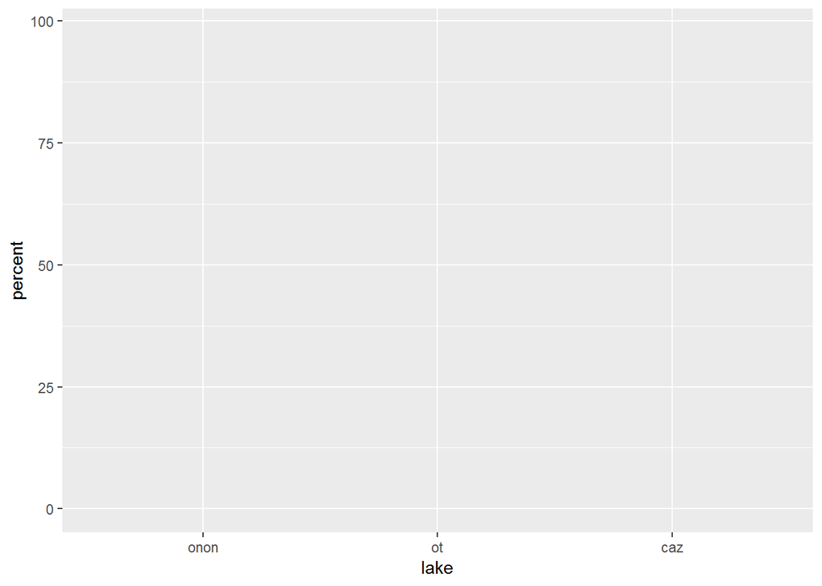

```r
pct.df %>%
ggplot(aes(x = lake, y = percent))
```

### Adding Layers (`+`)

**ggplot2** does not recognize the pipe operator (`%>%`), instead it uses `+` to add components to a plot.

Now let’s add data to the plot by adding a `+` at the end of `ggplot()` and then specifying the plot type we are interested in creating. All plot functions in **ggplot2** start with the prefix “geom_”.

### geom_boxplot

- **Definition:** create box and whisker plots
- **Link:** https://ggplot2.tidyverse.org/reference/geom_boxplot.html

Here we will create a box and whisker plot using `geom_boxplot()`. For this example, we will only focus on the percentage of Ephemeroptera (Mayflies) found within each lake by using the `filter()` function before the `ggplot()` function. The aesthetics have been specified within `ggplot()`, therefore `geom_boxplot()` can be called without any arguments.

```r
pct.df %>%
  filter(order == "ephemeroptera") %>%
ggplot(aes(x = lake, y = percent)) +
  geom_boxplot()
```

[output not shown]

#### Fill

The color of the interquartile boxes can be specified with `fill`. In this example, `fill = lake`, which **ggplot2** will automatically realize represents three categories and use a default color palette that is used to automatically color the plot. `fill` is specified within `aes()` within the `ggplot()` , and therefore this specification carries through to the subsequent `geom_boxplot()` call.

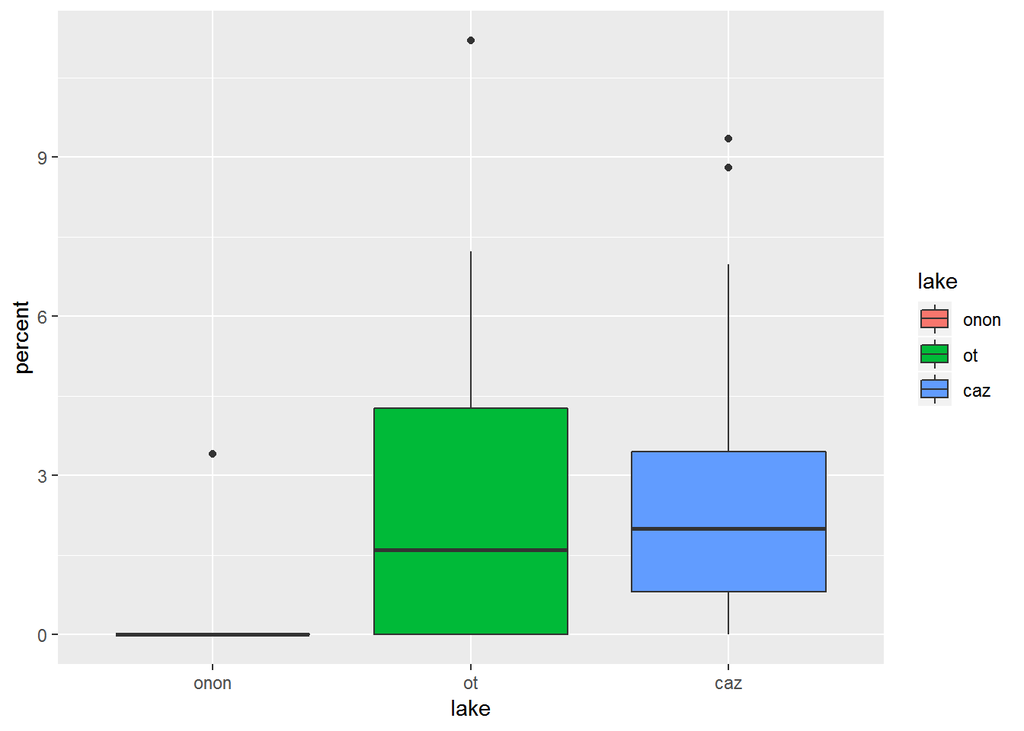

```r
pct.df %>%
  filter(order == "ephemeroptera") %>%
ggplot(aes(x = lake, y = percent, fill = lake)) +
  geom_boxplot()
```

#### Color

Color can be sepecified in a similar manner to Fill. In the plot below, we can see the difference between color and fill (the previous plot).

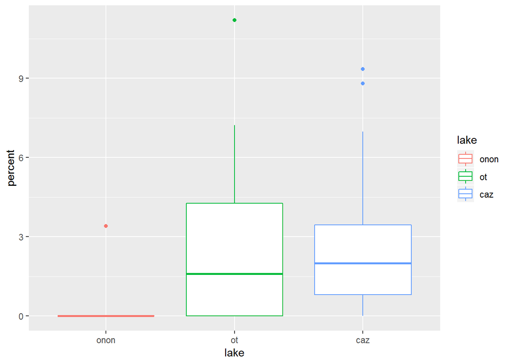

```r
pct.df %>%
  filter(order == "ephemeroptera") %>%
ggplot(aes(x = lake, y = percent, color = lake)) +
  geom_boxplot()
```

When I first started using **ggplot2**, I would frequently try to put the color or other aesthetic arguments outside of the `aes()` call. For example, in `ggplot(aes(x = lake, y = percent), color = lake)`, `color = lake` is not within the `aes()` call. Therefore, it has no effect on the plot (i.e., there is no color added to the plot).

```r
pct.df %>%
  filter(order == "ephemeroptera") %>%
ggplot(aes(x = lake, y = percent), color = lake) +
  geom_boxplot()
```

[output not shown]

`aes()` and the color or other aesthetics can also be specified within the `geom_boxplot()` call. This allows you to be more specific of which feature you want to recieve a given aesthetic.

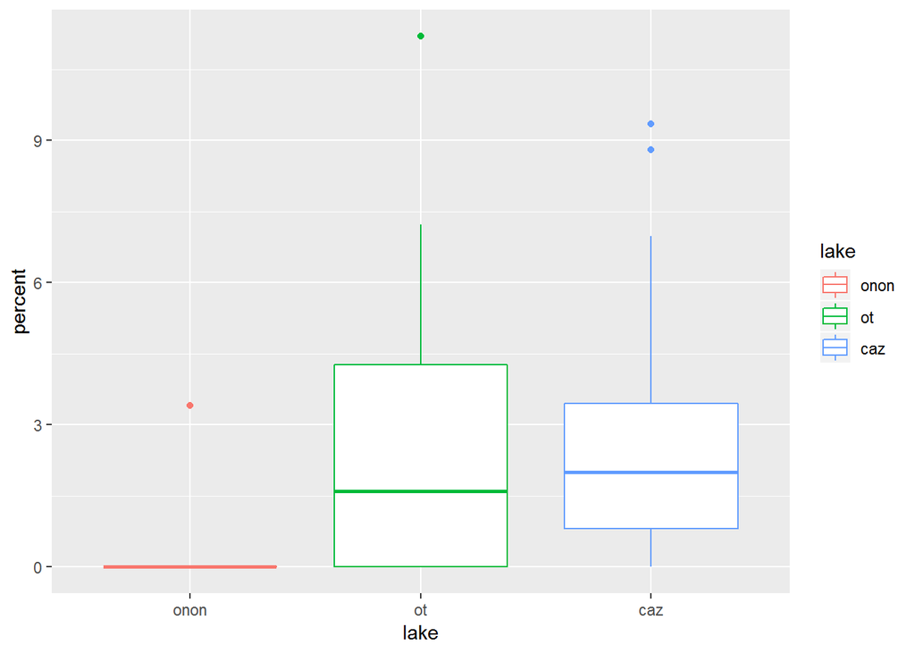

```r
pct.df %>%
  filter(order == "ephemeroptera") %>%
ggplot(aes(x = lake, y = percent)) +
  geom_boxplot(aes(color = lake))
```

Additionally, if you want to specify specific colors not based on features from your data frame (e.g., `lake`), then you can specify these colors within the `geom_boxplot()` call. Note, that `color` is **NOT** specified within an `aes()` call.

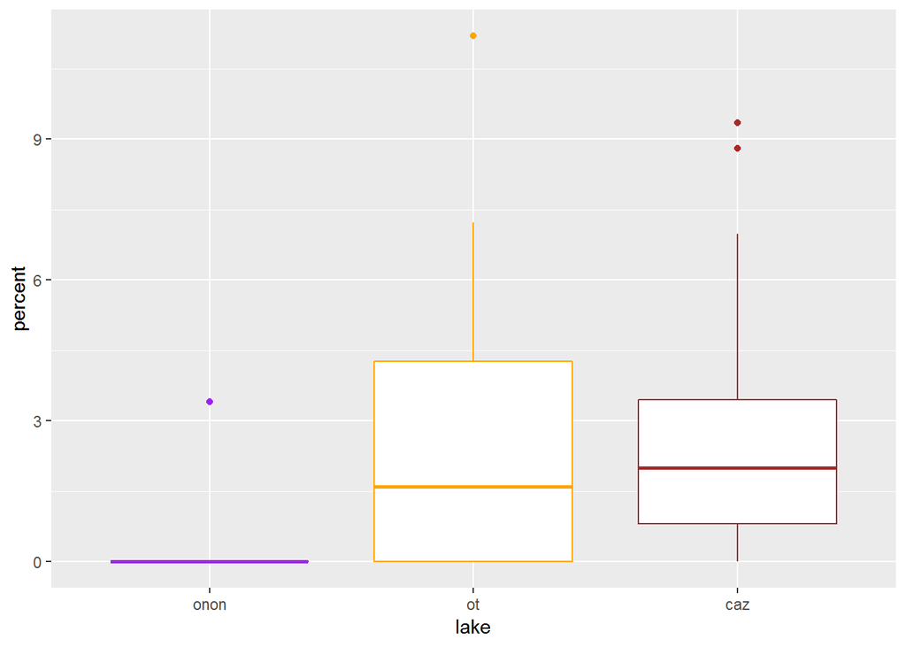

```r
pct.df %>%
  filter(order == "ephemeroptera") %>%
ggplot(aes(x = lake, y = percent)) +
  geom_boxplot(color = c("purple", "orange", "brown"))
```

If you do attempt to wrap manually specified colors, like `color = c("purple", "orange", "brown")`, within `aes()`, you will get an error.

```r
pct.df %>%
  filter(order == "ephemeroptera") %>%
ggplot(aes(x = lake, y = percent)) +
  geom_boxplot(aes(color = c("purple", "orange", "brown")))
```

```
## Error: Aesthetics must be either length 1 or the same as the data (48): colour
```

Also, trying to manually specify colors within the `ggplot()` call will have no effect on the plot.

```r
pct.df %>%
  filter(order == "ephemeroptera") %>%
ggplot(aes(x = lake, y = percent), color = c("purple", "orange", "brown")) +
  geom_boxplot()
```

[output not shown]

#### geom_point

- **Definition:** add points to a plot
- **Link:** https://ggplot2.tidyverse.org/reference/geom_point.html

Let’s add another layer to the plot above. `geom_point()` can be used to vizualize where the data points actually fall relative to the box and whisker plots.

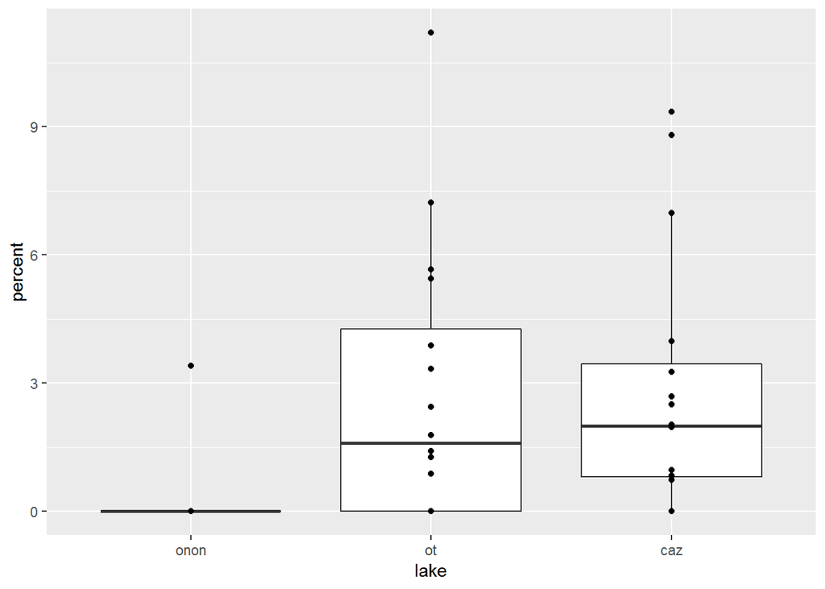

```r
pct.df %>%
  filter(order == "ephemeroptera") %>%
ggplot(aes(x = lake, y = percent)) +
  geom_boxplot() +
  geom_point()
```

#### geom_jitter

- **Definition:** add points to a plot that have been randomly offplaced from their actual position to avoid point overlap
- **Link:** https://ggplot2.tidyverse.org/reference/geom_jitter.html

In the geom_point plot above, it is not possible to know if a point represents a single sample or if there are more than one samples with the same value overlaid on one another. `geom_jitter()` can be used to randomly offset the points from thier actual position to avoid the overlap issue present in `geom_point()`.

In this example, `geom_jitter()` is used to offest the points overlaid on the box and whisker plots. The points are colored by `lake` within this call: `geom_jitter(aes(color = lake))`. Additionally, the outliers plotted from `geom_boxplot()` are hidden with `geom_boxplot(outlier.shape = NA)`. These outliers are represented in the `geom_jitter()` call; therefore, if the outliers were not removed from `geom_boxplot()`, these points would be represented twice.

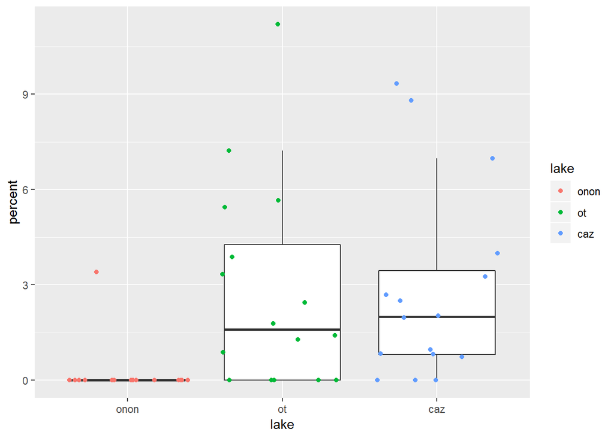

```r
pct.df %>%
  filter(order == "ephemeroptera") %>%
ggplot(aes(x = lake, y = percent)) +
  geom_boxplot(outlier.shape = NA) +
  geom_jitter(aes(color = lake))
```

Here we can see what happens if `color` is specified within the `ggplot()` call. Now the box and whisker lines and the points are colored by lake. This is in contrast to the last plot, where only the points were colored by lake.

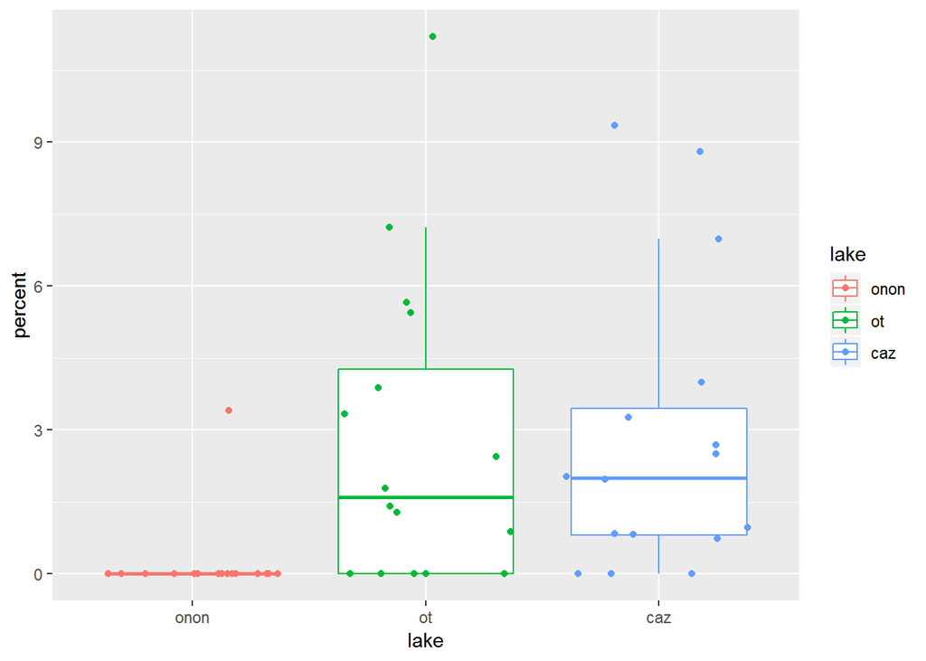

```r
pct.df %>%
  filter(order == "ephemeroptera") %>%
ggplot(aes(x = lake, y = percent, color = lake)) +
  geom_boxplot(outlier.shape = NA) +
  geom_jitter()
```

#### geom_violin

- **Definition:** create violin plots a way of visualizing point density and distribution
- **Link:** https://ggplot2.tidyverse.org/reference/geom_violin.html

This plot helps us to see that there are a lot of samples from Onondaga Lake (“onon”) that have no Ephemeroptera (percent = 0).

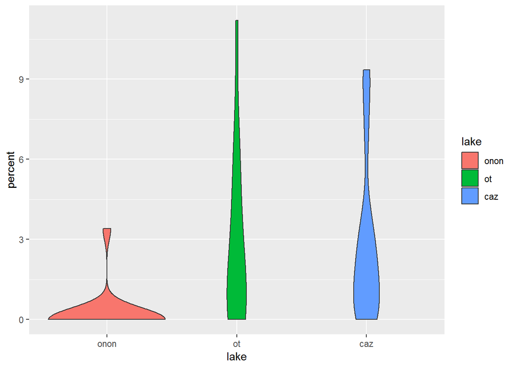

```r
pct.df %>%
  filter(order == "ephemeroptera") %>%
ggplot(aes(x = lake, y = percent, fill = lake)) +
  geom_violin()
```

#### geom_dotplot

- **Definition:** create dot plots or beeswarm plots a way of visualizing point density and distribution
- **Link:** https://ggplot2.tidyverse.org/reference/geom_dotplot.html

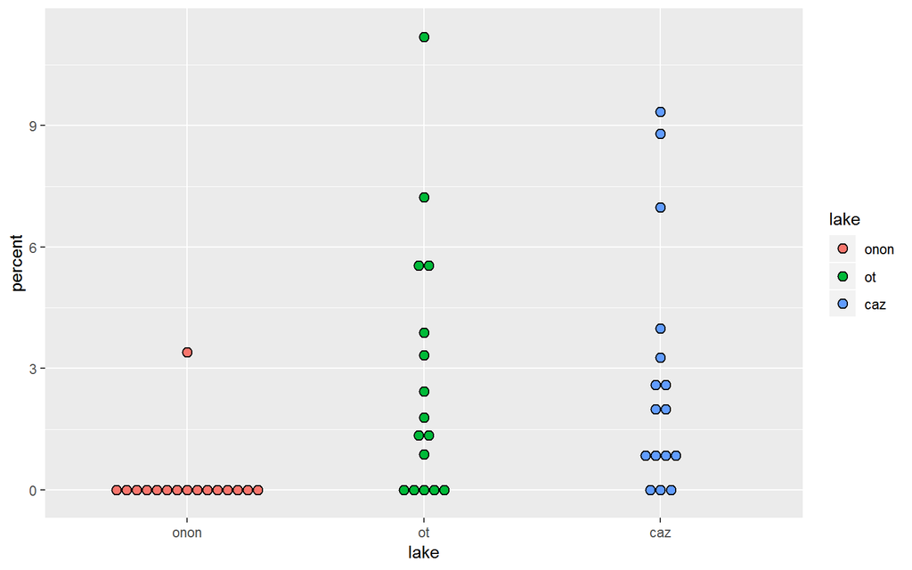

```r
pct.df %>%
  filter(order == "ephemeroptera") %>%
ggplot(aes(x = lake, y = percent, fill = lake)) +
  geom_dotplot(binaxis = "y",
               stackdir = "center",
               binwidth = 0.25)
```

`geom_dotplot()` could be overlaid on `geom_boxplot()`, which may be a better than a geom_jitter example.

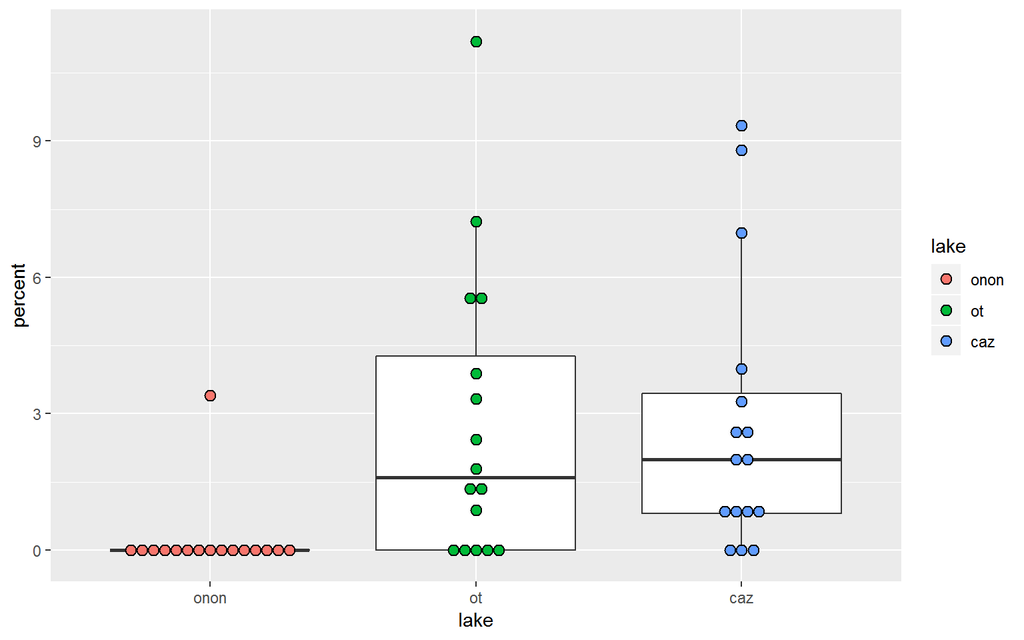

```r
pct.df %>%
  filter(order == "ephemeroptera") %>%
ggplot(aes(x = lake, y = percent)) +
  geom_boxplot(outlier.shape = NA) +
  geom_dotplot(aes(fill = lake),
               binaxis = "y",
               stackdir = "center",
               binwidth = 0.25)
```

#### geom_bar

- **Definition:** create bar plots
- **Link:** https://ggplot2.tidyverse.org/reference/geom_bar.html

```r
abund.df <- pct.df %>%
  group_by(lake, order) %>%
  summarise(count = median(count)) %>%
  ungroup() %>%
  mutate(order = forcats::fct_lump(factor(order),
                                   n = 5,
                                   w = count),
         order = forcats::fct_reorder(order, count, median, .desc = TRUE),
         lake = factor(lake, c("onon", "ot", "caz")))

DT::datatable(abund.df, options = list(scrollX = TRUE))
```

|  | lake | order | count |
| --- | --- | --- | --- |
| 1 | onon | amphipoda | 20 |
| 2 | onon | Other | 0 |
| 3 | onon | basommatophora | 0 |
| 4 | onon | Other | 0 |
| 5 | onon | Other | 0 |
| 6 | onon | diptera | 57.25 |
| 7 | onon | Other | 0 |
| 8 | onon | Other | 0 |
| 9 | onon | Other | 0 |
| 10 | onon | Other | 0 |

[output cut: 35 more lines]

Using `geom_bar()`, we can generate a bar plot. `state = "identity"` must be used when a `y` value is specified in `aes()`; otherwise, **ggplot2** will simiply count the number of `x` value instances to create a y-axis count.

**WARNING:** This plot is a quick example of `geom_bar()` and is not a good representation of the data. In this case, the median abundance was calculated for each taxon within each lake. `geom_bar()` is summing the median values per taxon per lake to produce this figure.

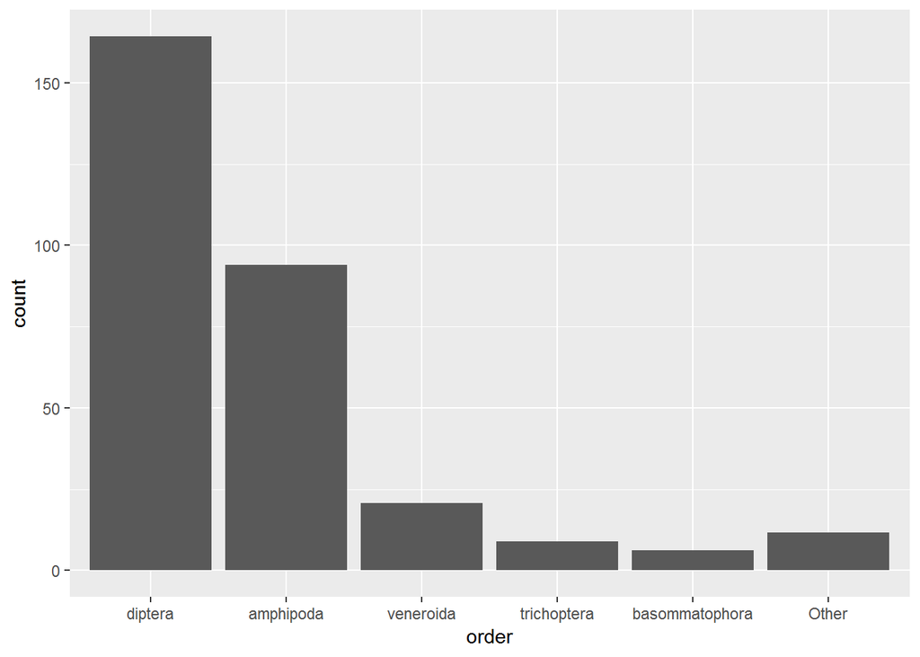

```r
abund.df %>%
ggplot(aes(x = order, y = count)) +
  geom_bar(stat = "identity")
```

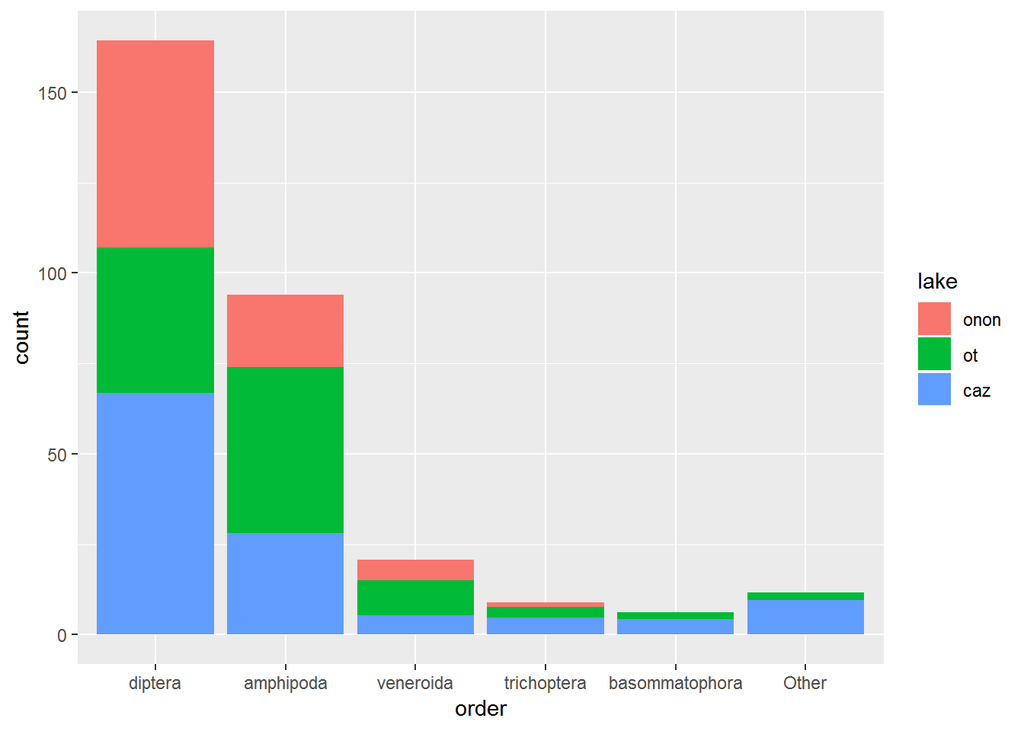

```r
abund.df %>%
ggplot(aes(x = order, y = count, fill = lake)) +
  geom_bar(stat = "identity")
```

`position = "dodge"` can be added to the `geom_bar()` call to make the bars for each lake appear side-by-side.

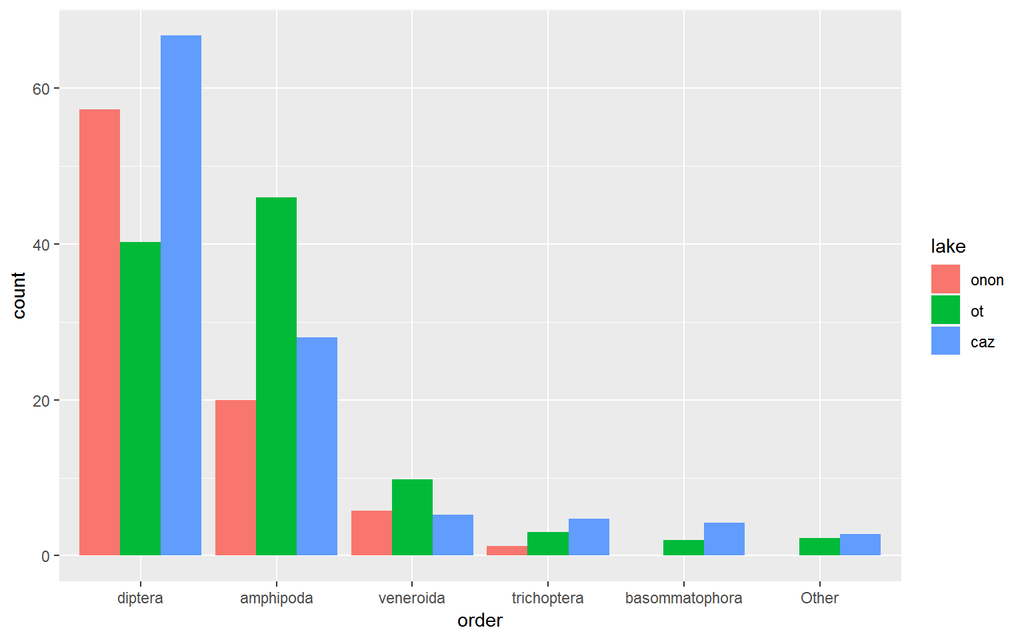

```r
abund.df %>%
ggplot(aes(x = order, y = count, fill = lake)) +
  geom_bar(stat = "identity",
           position = "dodge")
```

##### Stacked Bar Plots

Another great way to visualize this data is to create stacked bar plots. Stacked bar plots are almost always the better alternative to pie charts. In general, stack bar charts provide a more straight forward representation of quantity, which makes it easier to compare multiple stacked bar charts, then multiple pie charts.

- Note that in this section the x-axis now represents `lake`, the y-axis represents `count`, and the fill represents `order`.

Stacked bar plots can be created by adding `position = "stack"` to the `geom_bar()` call. This information is exactly the same as the `geom_bar()` plot above, where `position = "dodge"` but it is more condensed.

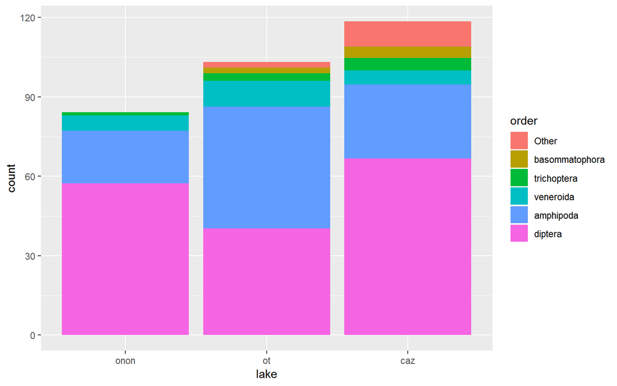

```r
abund.df %>%
  mutate(order = forcats::fct_reorder(order, count, median)) %>%
ggplot(aes(x = lake, y = count, fill = order)) +
  geom_bar(stat = "identity",
           position = "stack")
```

Stacked bar plots can also be created by adding `position = "fill"` to the `geom_bar()` call. This effectively calculates relative abundance, the percentage each taxon represents within a lake. This normalizes the data and makes it easier to compare between lakes.

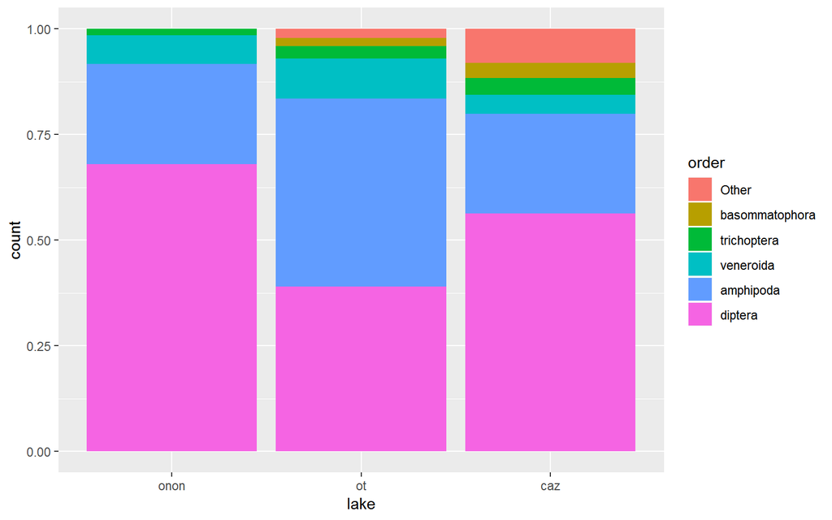

```r
abund.df %>%
  mutate(order = forcats::fct_reorder(order, count, median)) %>%
ggplot(aes(x = lake, y = count, fill = order)) +
  geom_bar(stat = "identity",
           position = "fill")
```

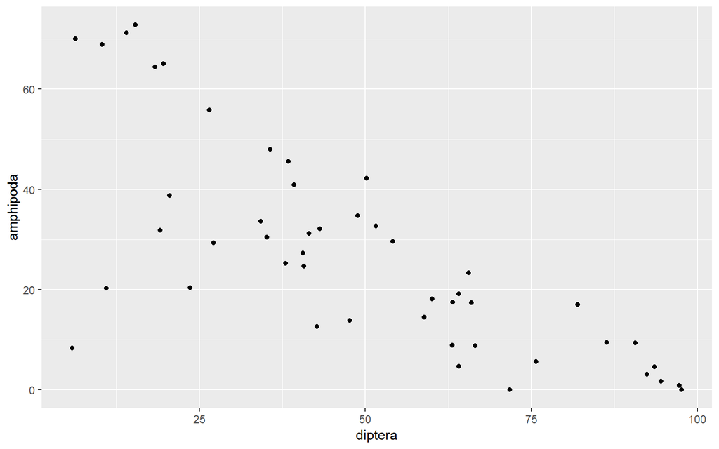

```r
pct.df %>%
  select(station_id, lake, percent, order) %>%
  spread(order, percent) %>%
ggplot(aes(x = diptera, y = amphipoda)) +
  geom_point()
```

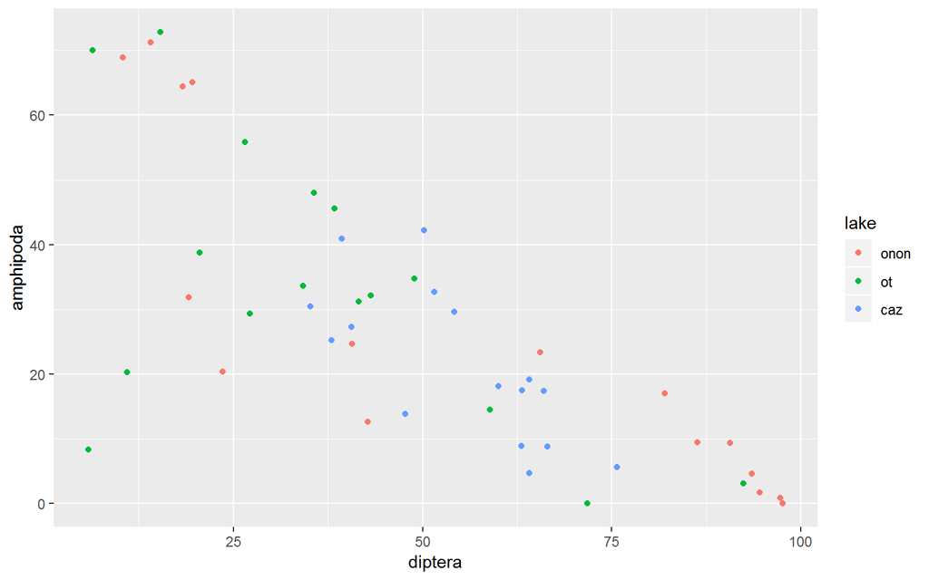

```r
pct.df %>%
  select(station_id, lake, percent, order) %>%
  spread(order, percent) %>%
ggplot(aes(x = diptera, y = amphipoda)) +
  geom_point(aes(color = lake))
```

#### geom_line

- **Definition:** draw a line between points
- **Link:** https://ggplot2.tidyverse.org/reference/geom_path.html

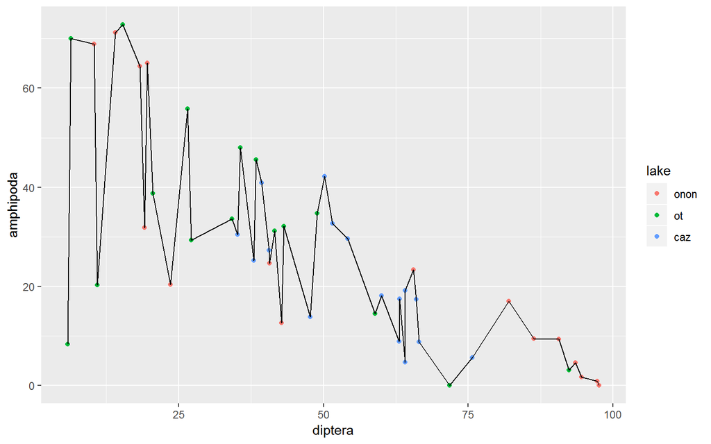

```r
pct.df %>%
  select(station_id, lake, percent, order) %>%
  spread(order, percent) %>%
ggplot(aes(x = diptera, y = amphipoda)) +
  geom_point(aes(color = lake)) +
  geom_line()
```

#### geom_smooth

- **Definition:** plot a linear model (e.g., linear model, LOESS)
- **Link:** https://ggplot2.tidyverse.org/reference/geom_smooth.html

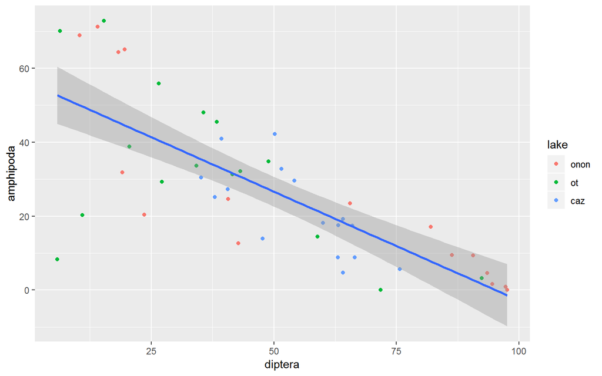

```r
pct.df %>%
  select(station_id, lake, percent, order) %>%
  spread(order, percent) %>%
ggplot(aes(x = diptera, y = amphipoda)) +
  geom_point(aes(color = lake)) +
  geom_smooth(method = "lm", formula = y ~ x)
```

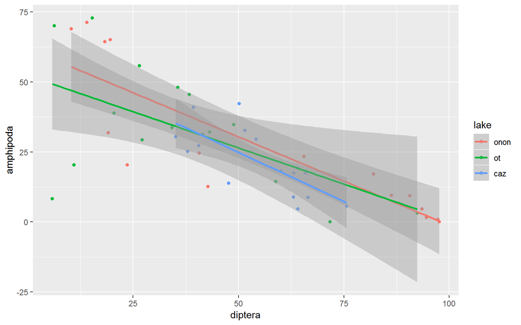

```r
pct.df %>%
  select(station_id, lake, percent, order) %>%
  spread(order, percent) %>%
ggplot(aes(x = diptera, y = amphipoda, color = lake)) +
  geom_point() +
  geom_smooth(method = "lm", formula = y ~ x)
```

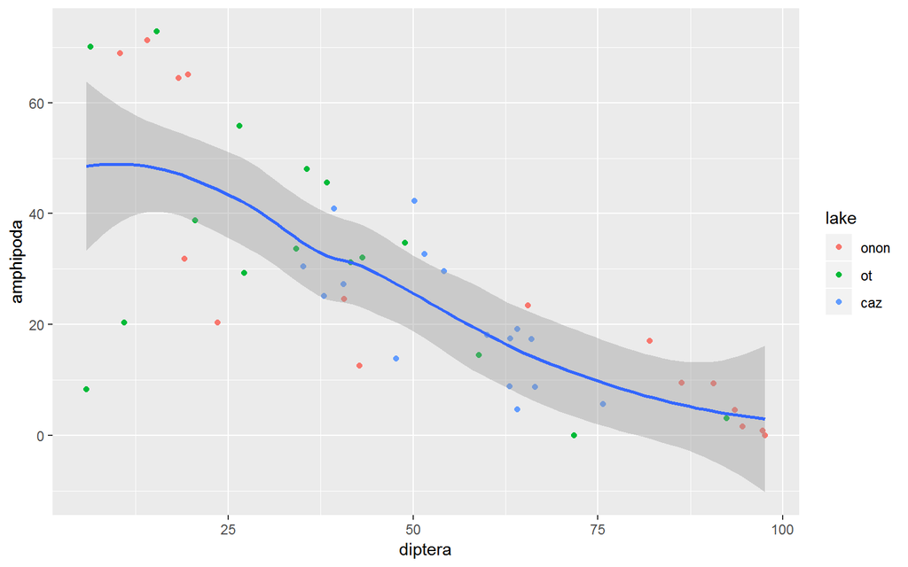

```r
pct.df %>%
  select(station_id, lake, percent, order) %>%
  spread(order, percent) %>%
ggplot(aes(x = diptera, y = amphipoda)) +
  geom_point(aes(color = lake)) +
  geom_smooth(method = "loess", formula = y ~ x)
```

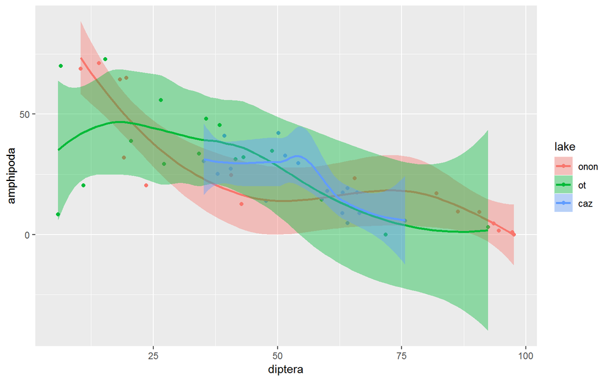

```r
pct.df %>%
  select(station_id, lake, percent, order) %>%
  spread(order, percent) %>%
ggplot(aes(x = diptera, y = amphipoda, color = lake, fill = lake)) +
  geom_point(aes(color = lake)) +
  geom_smooth(method = "loess", formula = y ~ x)
```

#### facet_wrap

- **Definition:** replicate a plot by a specified feature or features
- **Link:** https://ggplot2.tidyverse.org/reference/facet_wrap.html

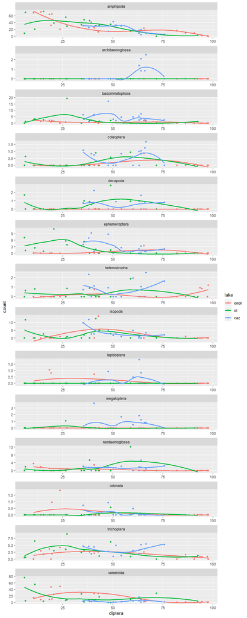

```r
pct.df %>%
  select(station_id, lake, percent, order) %>%
  spread(order, percent) %>%
  gather(order, count, amphipoda:veneroida, -diptera) %>%
ggplot(aes(x = diptera, y = count, color = lake, fill = lake)) +
  geom_point(aes(color = lake)) +
  geom_smooth(method = "loess", formula = y ~ x, se = FALSE) +
  facet_wrap(~order,
             ncol = 1,
             scales = "free")
```